# 390R Homework 4

**Due: Tuesday, November 15 at 2:30 pm**

# 1 Penguin Data

Install and load the package palmerpenguins. We will work on the penguins dataset for this question (figure from www.123RF.com). You can choose the themes you like for the figures. (I use theme_bw())

[figure not shown]

1. What are the percentages of missing values in bill_length_mm, bill_depth_mm, sex? (recall the percent() function in scales package)
2. What are the means and medians of the body mass for male and female penguins of each species? (Remove the NAs in the sex first)
3. We would like to compare the body mass between males and females across specifies. Make the following plot. What do you find? (Note: x label is removed, and the unit of y axis is changed to kilogram (kg))

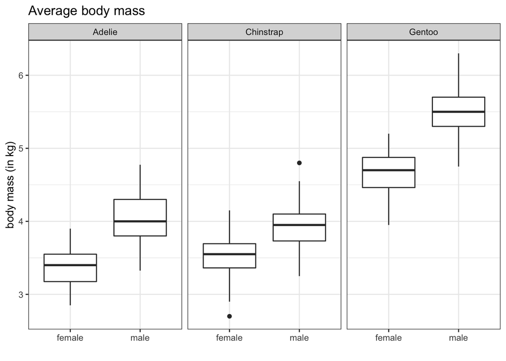

4. We would like to know the trend of the average body mass over the three years. Make the following plot. What do you find?

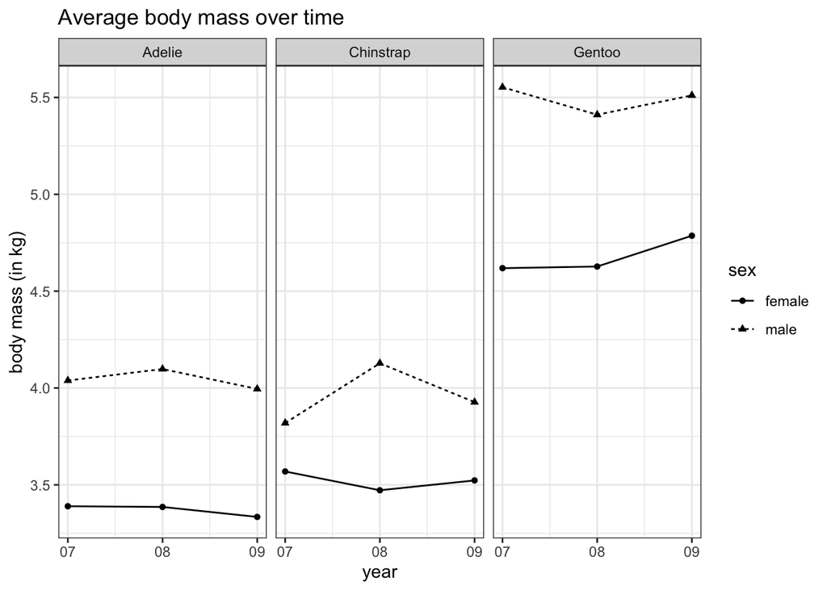

5. We would like to know how the flipper length relates to the body mass and the bill length. Make the following two plots (Note: the units of the variables are changed). What do you find?

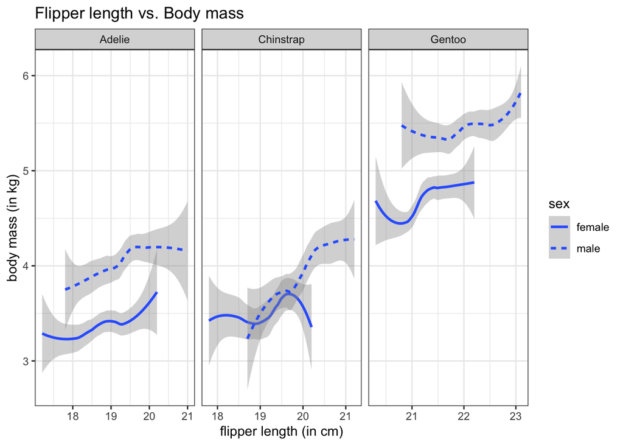

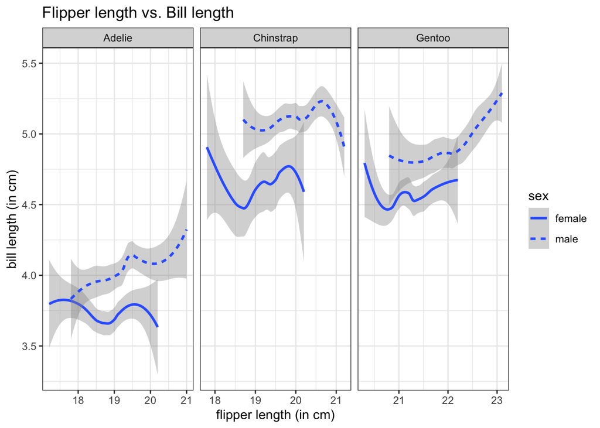

# 2 More on `flights` dataset

1. Find out the most frequent destination airports for all flights departing from New York City (in terms of total number of flights).
2. Passengers are often frustrated when their flight departs late, but are not as annoyed if, in the end, pilots can make up some time during the flight.
   - Extract the flights data in October and calculate the “gained time in the air” as the difference tween arr_delay and dep_delay. Make a scatterplot of dep_delay vs. the “gained time” and add a smooth line. What do you find? (You may need to zoom in to see more clearly).
   - The “gained time” defined above may not be reasonable because long distance flight may be more likely to gain more. Replace the “gained time” with the “gained time per hour” and do a similar analysis.
3. Plot the following bar chart on the number of flights took off every 3 hours. You need to
   1. remove cancelled flights
   2. create a variable which equals 0 if the flight took off between 0 and 3 am, equals 1 if took off between 3 and 6 am…
   3. make the bar chart
   4. change the labels

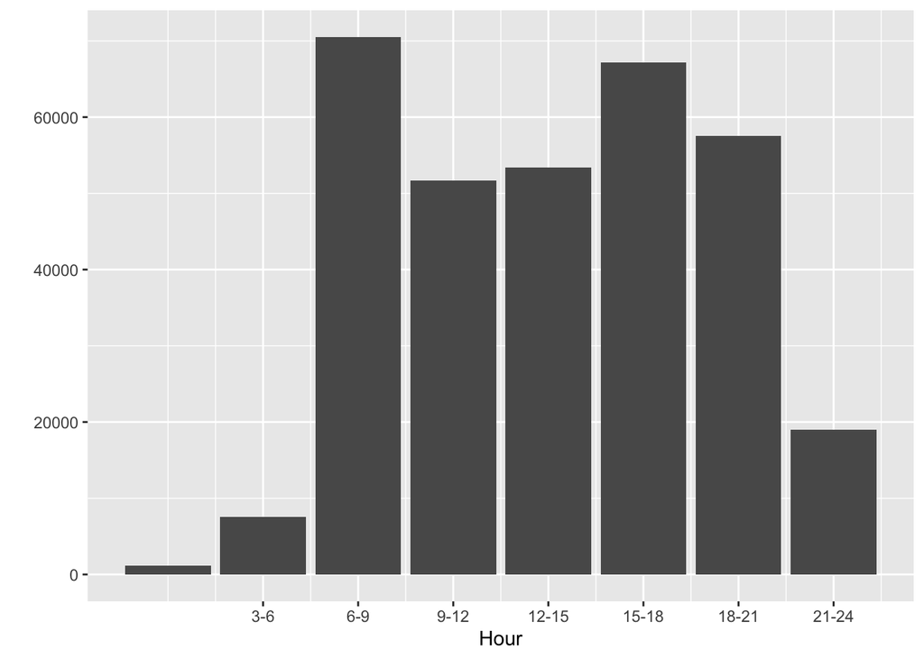

# 3 More on babynames

1. Select the baby names in 2010 and used by no less than 10000 babies. (optional) Obtain the names that are used by no less than 10000 boys and 10000 girls.
2. Find out the longest names (in terms of the number of letters) in 2010. (str_length() calculates the number of letters of a string).
3. Make a time series plot (line plot) of the number of babies having a long name (>=10 letters). What do you find? Below is an example. (Note: you need to take into account the number of times a name appears in n variable)

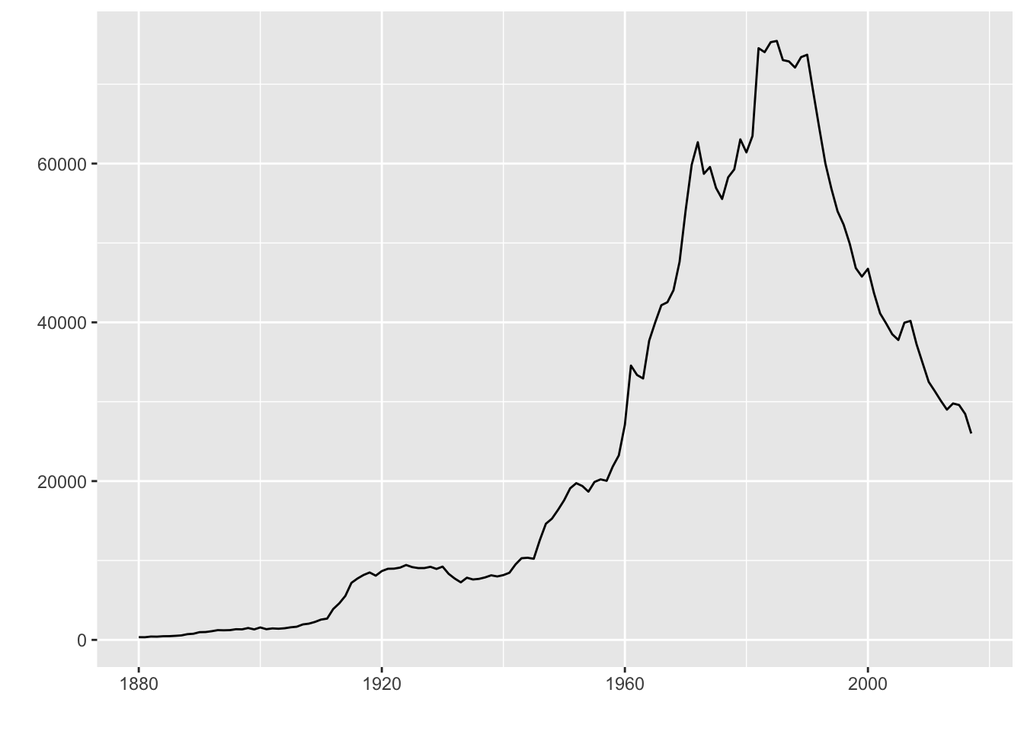

4. (optional) Use proportions (number of long name babies/ total number of babies in that year) instead of counts for the previous question.

# 4 Using `arrange()` and `mutate()` with `group_by()`

1. Let’s explore how `arrange()` works with `group_by()` using a toy dataset.

```r
toy <- tibble(
  x = c(4, 2, 2, 3, 3, 1, 3, 4, 5),
  group = c("c", "b", "a", "c", "b", "a", "a", "b", "c")
)
```

Suppose we would like to sort x in an increasing order within each group like this

```
## # A tibble: 9 × 2
## # Groups:   group [3]
##       x group
##   <dbl> <chr>
## 1     1 a
## 2     2 a
## 3     3 a
## 4     2 b
## 5     3 b
## 6     4 b
## 7     3 c
## 8     4 c
## 9     5 c
```

Does the following code work?

```r
toy %>%
  group_by(group) %>%
  arrange(x)
```

Make some changes to sort within each group. (Hint: there are two ways. 1. sort with multiple variables; 2. check the .by_group argument of arrange() function)

2. The rank() function gives the rank of a variable. Using the babynames dataset to obtain the top two popular baby names for each year from 2010 to 2017.